# Aula 5 - Introdução à Econometria

Autor

João Ricardo F. de Lima

Data de Publicação

20 de julho de 2026

# Pressupostos do Modelo Clássico de Regressão Linear

O Modelo Clássico de Regressão Linear se baseia em algumas hipóteses:

1. O modelo de regressão é linear nos parâmetros;
2. Os regressores são fixos (não aleatórios) em amostras repetidas (análise de regressão é condicional aos valores de X, ou seja, $E(Y|X)$;
3. Dados os valores de X, $E(\mu|X)=0$: Isso significa que não importa qual valor escolhemos para x, o termo de erro $\mu$ não deve apresentar nenhum padrão sistemático e deve ter média igual a zero.

Considere o caso em que, incondicionalmente, $E(\mu)=0$, mas para valores altos e baixos de x, o termo de erro tende a ser positivo e para valores médios de x, o erro tende a ser negativo. Pode-se usar R para construir tal exemplo.

Começamos criando um vetor contendo valores uniformemente distribuídos no intervalo $[−5,5]$. Isso pode ser feito com a função `runif()`. Também precisamos simular o termo de erro. Para isso, geramos números aleatórios normalmente distribuídos com média igual a 0 e variância igual a 1 usando `rnorm()`. Os valores de Y são obtidos como uma função quadrática dos valores de X e do erro.

Depois de gerar os dados, estima-se um modelo de regressão simples e um modelo quadrático que também inclui o regressor $X^2$. Por fim, plota-se os dados simulados e adiciona-se a linha de regressão estimada de um modelo de regressão simples, bem como as previsões feitas com um modelo quadrático para comparar o ajuste graficamente.

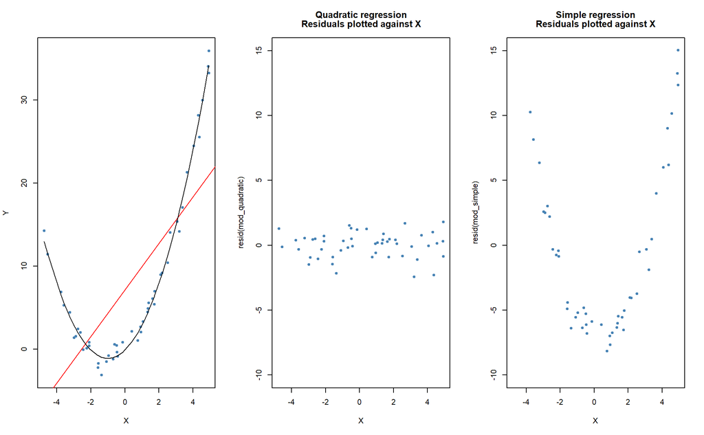

```r
# definir uma semente para tornar os resultados reproduzíveis
set.seed(321)

# simular os dados
X <- runif(50, min = -5, max = 5)
u <- rnorm(50, sd = 1)

# a verdadeira relação
Y <- X^2 + 2 * X + u

# estimar um modelo de regressão simples, mas incorreto
mod_simple <- lm(Y ~ X)

# estimar um modelo de regressão quadrático, correto
mod_quadratic <- lm( Y ~ X + I(X^2) )

# Previsão usando modelo quadrático
prediction <- predict(lm(Y ~ X + I(X^2)), data.frame(X = sort(X)))

# plot dos resultados
par(mfrow=c(1,3))

plot( Y ~ X, col = "steelblue", pch = 20, xlab = "X", ylab = "Y")
abline( mod_simple, col = "red")

#red line = incorrect linear regression (this violates the first OLS assumption)
lines( sort(X), prediction)
# black line = correct quadratic regression
plot( resid(mod_quadratic) ~ X , col = "steelblue", pch = 20, main=c("Quadratic regression","Residuals plotted against X"), ylim=c(-10,15) )

plot( resid(mod_simple) ~ X , col = "steelblue", pch = 20,
main=c("Simple regression","Residuals plotted against X"),
ylim=c(-10,15) )
```

4. Dados distribuídos de forma independente e idêntica (iid): A maioria dos esquemas de amostragem usados ao coletar dados de populações produz amostras iid.. Por exemplo, pode-se usar o gerador de números aleatórios de R para selecionar aleatoriamente os números de matrículas dos alunos da FACAPE e registrar a idade e as remunerações $(X_i,Y_i)$ dos alunos correspondentes. Este é um exemplo típico de amostragem aleatória simples e garante que todos os $(X_i,Y_i)$ são sorteados aleatoriamente da mesma população.
5. Grandes outliers (valores discrepantes) não são desejados: É fácil encontrar situações em que podem ocorrer observações extremas, ou seja, observações que se desviam consideravelmente da faixa usual dos dados. Tais observações são chamadas de *outliers*. Tecnicamente falando, esta suposição exige que $(X_i,Y_i)$ tenha uma curtose finita.

Casos comuns em que se quer excluir ou (se possível) corrigir tais valores discrepantes são quando eles são aparentemente erros de digitação, erros de conversão ou erros de medição. Mesmo que pareça que as observações extremas foram registradas corretamente, é aconselhável excluí-las antes de estimar um modelo, pois o MQO sofre de sensibilidade a outliers.

O que isto significa? Pode-se mostrar que observações extremas recebem grande peso na estimativa dos coeficientes de regressão desconhecidos ao usar MQO. Portanto, outliers podem levar a estimativas fortemente distorcidas de coeficientes de regressão.

O código a seguir usa dados de amostra gerados usando as funções de número aleatório do R rnorm() e runif(). Estima-se dois modelos de regressão simples, um baseado no conjunto de dados original e outro usando um conjunto modificado onde uma observação é alterada para um outlier e, em seguida, plota-se os resultados. Para entender o código completo, a função sort() classifica as entradas de um vetor numérico em ordem crescente.

O resultado é bastante impressionante: a linha de regressão estimada com o outlier (linha preta) difere muito daquela que ajusta bem os dados (linha vermelha)).

```r
# definir uma semente para tornar os resultados reproduzíveis
set.seed(123)

# gerar os dados
X <- sort(runif(10, min = 30, max = 70))
Y <- rnorm(10 , mean = 200, sd = 50)
Y[9] <- 2000

# estima o modelo com outlier
fit <- lm(Y ~ X)
summary(fit)
```

```
Call:
lm(formula = Y ~ X)

Residuals:
   Min     1Q Median     3Q    Max
-458.1 -275.9 -136.7   -1.9 1402.1

Coefficients:
            Estimate Std. Error t value Pr(>|t|)
(Intercept)  -509.79     867.88  -0.587    0.573
X              16.86      15.98   1.055    0.322

Residual standard error: 565.4 on 8 degrees of freedom
Multiple R-squared:  0.1221,    Adjusted R-squared:  0.01236
F-statistic: 1.113 on 1 and 8 DF,  p-value: 0.3223
```

```r
# estima o modelo sem outlier
fit2 <- lm(Y[-9] ~ X[-9])

summary(fit2)
```

```
Call:
lm(formula = Y[-9] ~ X[-9])

Residuals:
    Min      1Q  Median      3Q     Max
-77.174 -29.808   2.606  31.570  54.932

Coefficients:
            Estimate Std. Error t value Pr(>|t|)
(Intercept)  276.152     78.191   3.532  0.00957 **
X[-9]         -1.342      1.479  -0.908  0.39418
---
Signif. codes:  0 '***' 0.001 '**' 0.01 '*' 0.05 '.' 0.1 ' ' 1

Residual standard error: 48.5 on 7 degrees of freedom
Multiple R-squared:  0.1053,    Adjusted R-squared:  -0.02249
F-statistic: 0.824 on 1 and 7 DF,  p-value: 0.3942
```

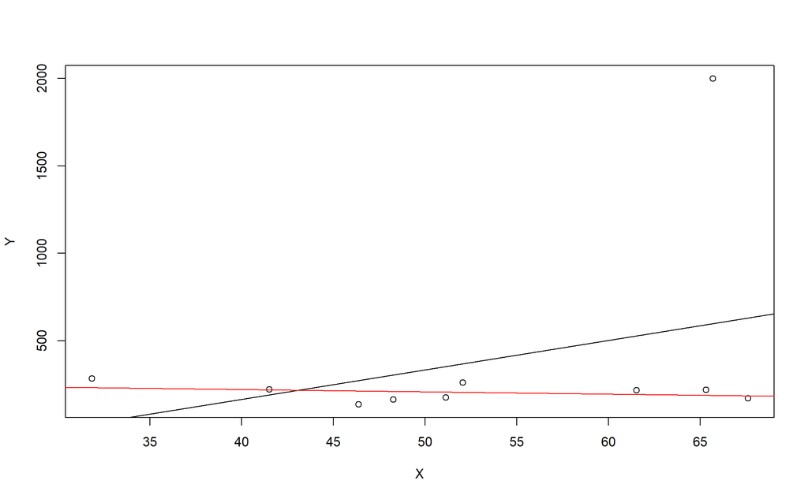

```r
# plota os resultados
plot(Y ~ X)
abline(fit)
abline(fit2, col = "red")
```

Com isso, é possível demonstrar que o estimador de MQO não é viesado: $E(\hat{\beta}_0)=\beta_0$ e $E(\hat{\beta}_1)=\beta_1$.

**Intepretação de não viesado**

Os coeficientes estimados podem ser menores ou maiores, dependendo da amostra que é o resultado de um sorteio aleatório.

No entanto, em média, eles serão iguais aos valores que caracterizam a verdadeira relação entre y e x na população.

“Em média” significa que, a amostragem foi repetida, ou seja, foram sorteadas amostras aleatórias e repetidas as estimações diversas vezes.

Em uma dada amostra, as estimativas podem diferir consideravelmente dos valores verdadeiros. A demonstração será feita na parte de regressão múltipla.

Continuando com as hipóteses do MCRL, além de saber que a distribuição amostral de $\hat{\beta}_1$ está centrada em torno de $\beta_1$, é importante saber o quão distante, em média, pode-se esperar que $\hat{\beta}_1$ esteja de $\beta_1$:

4. A variância de cada observação $u$, dados os valores de X, é constante - *homocedástico*:

$$\begin{equation}
var (u|x)=\sigma^2
\tag{2}
\end{equation}$$

O valor da variável independente não deve conter informação sobre a variabilidade dos fatores não observados.

Como $var(u|x)=E(u^2|x)-[E(u|x)]^2$ e $E(u|x)=0$, $\sigma^2=E(u^2|x)$.

Portanto, $\sigma^2=E(u^2)=var(u)$, pois $E(u)=0$.

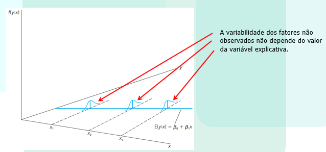

Homocedasticidade

Fonte: Wooldridge, 2017.

Outras hipóteses do MCRL:

5. Não há autocorrelação entre os termos de erro.

$$\begin{equation}
cov (u_i,u_j|X)=0
\tag{3}
\end{equation}$$

6. Nao existe multicolinearidade perfeita;
7. O modelo está corretamente especificado;
8. Os resíduos seguem a distribuição :

$$\begin{equation}
u \sim N(0,\sigma^2)
\tag{4}
\end{equation}$$

# Normalidade dos Resíduos

O MCRL assume que cada $u_i$ é distribuído Normalmente com:

**Média Zero**

$$E(u_i)=0$$
**Variância Constante**

$$E[u_i-E(u_i)]^2=E(u_i^2)= \sigma^2$$

**Covariância Zero**

$$E{[(u_i-E(u_i)][u_j-E(u_j)]}=E(u_i,u_j) =0 \quad \forall \quad i\neq j$$

ou dito de outra forma

$$\begin{equation}
u_i \sim N(0,\sigma^2)
\tag{5}
\end{equation}$$

se duas variáveis são normalmente distribuídas e não são autocorrelacionadas, são chamadas de independentes. Assim, pode-se reescrever (5) da seguinte forma:

$$\begin{equation}
u_i \sim IID(0,\sigma^2)
\tag{6}
\end{equation}$$

## Teste de Normalidade de Jarque-Bera

Para se testar Normalidade dos resíduos pode-se fazer um histograma dos resíduos e observar seu comportamento ou fazer o **teste de Jarque-Bera (JB)** de Normalidade dos resíduos. O teste de Jarque-Bera tem como pressuposto que a amostra seja grande.

O teste calcula a simetria da distribuição dos resíduos e a Curtose e usa a seguintes estatística de teste:

$$\begin{equation}
JB=n [\frac{S^2}{6}+ \frac{(K-3)^2}{24}]
\tag{7}
\end{equation}$$

que segue a distribuição de $\chi^2$ com 2 graus de liberdade. A **hipótese nula** do teste de JB é que *os resíduos seguem a distribuição Normal*.

## Exemplo no R

```r
#Limpa o Ambiente Global
rm(list=ls())

#Pode usar dados de outros softwares
library(wooldridge)
library(dplyr)
library(htmltools)
library(knitr)
library(kableExtra)
library(tseries)

#Carregar dados no computador
data('ceosal1')

# Estimação do Modelo
regressao1 <- lm(salary ~ roe, data=ceosal1)

#Teste de Normalidade de Jarque-Bera - precisa do pacote tseries
jarque.bera.test(regressao1$residuals)
```

```
    Jarque Bera Test

data:  regressao1$residuals
X-squared = 31121, df = 2, p-value < 2.2e-16
```

Como o valor de probabilidade é menor do que 0,10, rejeitamos a hipótese nula, ou seja, os resíduos não seguem a distribuição Normal.

## Teste de Normalidade de Shapiro-Wilk

O teste de Shapiro-Wilk é um teste de normalidade que testa, com base na estatística W, se um conjunto de dados segue a distribuição Normal. A estatística é:

$$\begin{equation}
W=\frac{(\sum_{i=1}^{n}a_ix_i)^2}{(\sum_{i=1}^{n}x_i-\bar{x})^2}
\tag{8}
\end{equation}$$

Em que $x_i$ são os dados ordenados em ordem crescente (amostra classificada); $\bar{x}$ é a média amostral; as constantes $a_i$ são constantes geradas pelas médias, variâncias e covariâncias das estatísticas de ordem de uma amostra de tamanho n de uma distribuição Normal.

A ideia é comparar a ordenação dos dados observados com os valores esperados se a distribuição fosse normal. O teste gera uma estatística $W$, que mede o quão próximos estão os dados da normalidade. O Valor calculado fica entre 0 e 1, sendo que quanto mais perto de 1, mais normal é a distribuição.

## Estatística Omnibus (D’Agostino & Pearson) de Normalidade

O teste **Omnibus D’Agostino e Pearson** combina duas estatísticas de normalidade, a assimetria e a curtose padronizadas. A ideia é que, se os resíduos seguem de fato uma distribuição normal, eles devem ter assimetria $\approx$ 0 e excesso de curtose $\approx$ 0.

É definida como a soma dos quadrados das estatísticas de assimetria e curtose padronizadas:

$$K^2 = Z_1^2 + Z_2^2 \sim \chi^2(2)$$

Coeficiente de assimetria amostra é definido por

$$\hat{g}_1 = \frac{\frac{1}{n} \sum_{i=1}^n (x_i - \bar{x})^3}{\left( \frac{1}{n} \sum_{i=1}^n (x_i - \bar{x})^2 \right)^{3/2}}$$

A estatística padronizada é

$$Z_1 = \frac{\sqrt{n(n-1)}}{n-2} \cdot \frac{\hat{g}_1}{\sqrt{\frac{6(n-2)}{(n+1)(n+3)}}}$$

O excesso de curtose amostral é definido por:

$$\hat{g}_2 = \frac{\frac{1}{n} \sum_{i=1}^n (x_i - \bar{x})^4}{\left( \frac{1}{n} \sum_{i=1}^n (x_i - \bar{x})^2 \right)^{2}} - 3$$

A Estatística padronizada é

$$Z_2 = \frac{\hat{g}_2 - \frac{6}{n+1}}{\sqrt{\frac{24n(n-2)(n-3)}{(n+1)^2 (n+3)(n+5)}}}$$

No output do statsmodels em Python, aparece a **Omnibus statistic** como parte dos testes de normalidade dos resíduos da regressão.

## Exemplo no R de testes de Normalidade

```r
# Estimação do Modelo
regressao1 <- lm(salary ~ roe, data=ceosal1)

#Teste de Normalidade de Shapiro-Wilk
shapiro.test(regressao1$residuals)
```

```
    Shapiro-Wilk normality test

data:  regressao1$residuals
W = 0.41717, p-value < 2.2e-16
```

Como o valor de probabilidade é menor do que 0,10, rejeitamos a hipótese nula, ou seja, os resíduos não seguem a distribuição Normal.

## Outras análises que podem ser feitas com os resíduos

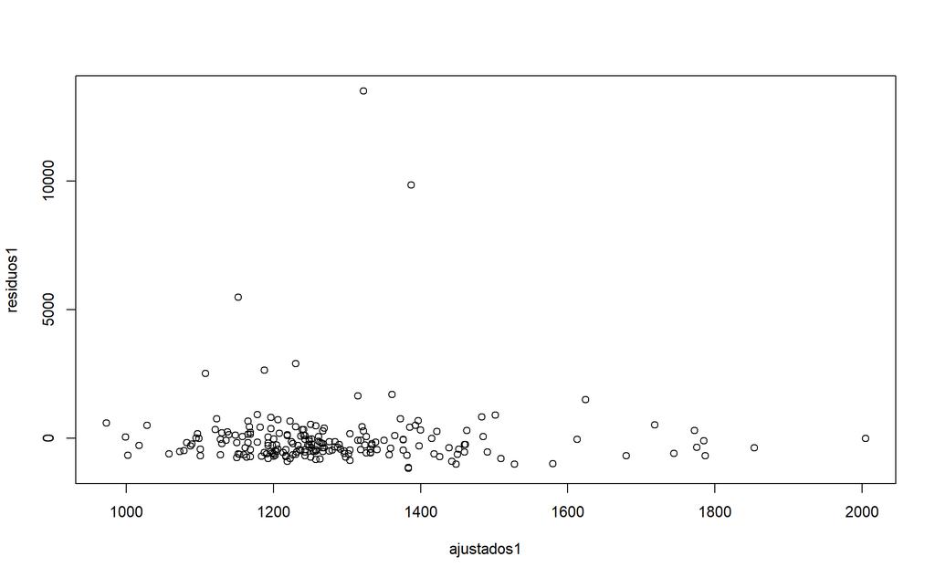

```r
#Salvando os residuos do modelo e os valores estimados
residuos1 <- regressao1$residuals
ajustados1 <- regressao1$fitted.values

# Fazendo um gráfico para verificar algum padrão
plot(ajustados1, residuos1)
```

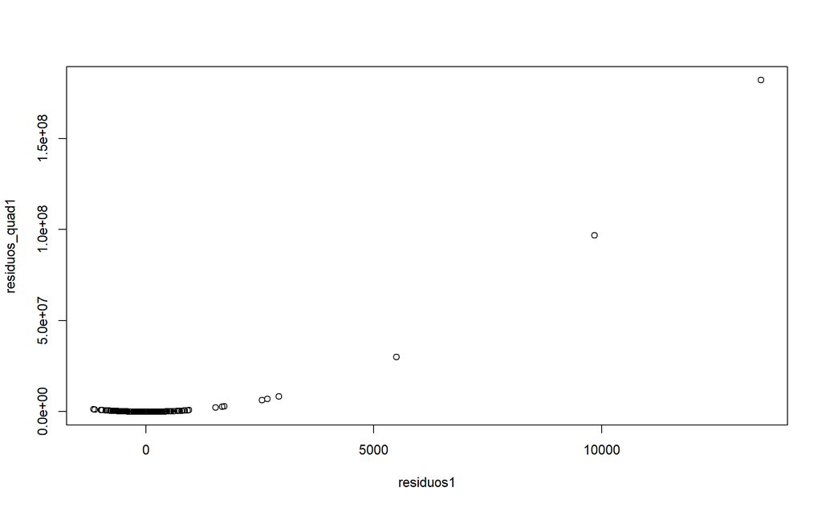

```r
# Outra possibilidade de gráfico para verificar algum padrão
residuos_quad1 = (residuos1)^2
plot(residuos1, residuos_quad1)
```

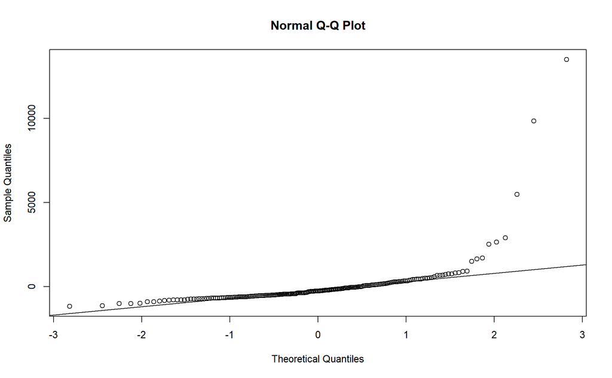

```r
#Outras análises de resíduos

#Gráfico QQ
qqnorm(residuos1)
qqline(residuos1)
```

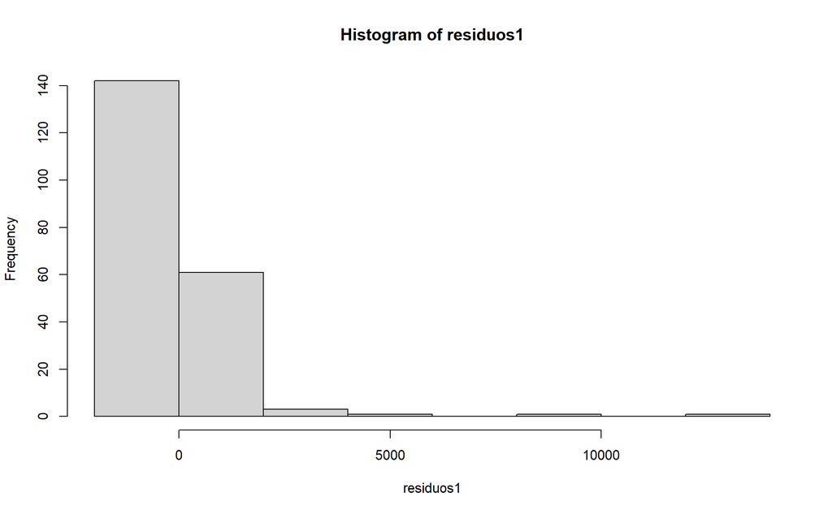

```r
hist(residuos1) #histograma dos resíduos
```

## Análise de Normalidade no Python

```python
import wooldridge
import pandas as pd
import numpy as np
import matplotlib.pyplot as plt
import seaborn as sns
import statsmodels.formula.api as smf
import scipy.stats as stats

#Carregar dados no computador
ceosal1 = wooldridge.data('ceosal1')

# Regressão Linear Simples

reg1 = smf.ols('salary ~ roe', data = ceosal1)

# Outra Opção de Output de Resultado

result = reg1.fit()
print(result.summary())
```

```
                            OLS Regression Results
==============================================================================
Dep. Variable:                 salary   R-squared:                       0.013
Model:                            OLS   Adj. R-squared:                  0.008
Method:                 Least Squares   F-statistic:                     2.767
Date:                seg, 20 jul 2026   Prob (F-statistic):             0.0978
Time:                        09:43:05   Log-Likelihood:                -1804.5
No. Observations:                 209   AIC:                             3613.
Df Residuals:                     207   BIC:                             3620.
Df Model:                           1
Covariance Type:            nonrobust
==============================================================================
                 coef    std err          t      P>|t|      [0.025      0.975]
------------------------------------------------------------------------------
Intercept    963.1913    213.240      4.517      0.000     542.790    1383.592
roe           18.5012     11.123      1.663      0.098      -3.428      40.431
==============================================================================
Omnibus:                      311.096   Durbin-Watson:                   2.105
Prob(Omnibus):                  0.000   Jarque-Bera (JB):            31120.902
Skew:                           6.915   Prob(JB):                         0.00
Kurtosis:                      61.158   Cond. No.                         43.3
==============================================================================

Notes:
[1] Standard Errors assume that the covariance matrix of the errors is correctly specified.
```

```python
# Extrai os Resíduos

residuals = result.resid

shapiro_test = stats.shapiro(residuals)
print(f"Shapiro-Wilk teste estatistica: {shapiro_test.statistic}")
```

```
Shapiro-Wilk teste estatistica: 0.4171696951563144
```

```python
print(f"Shapiro-Wilk teste p-value: {shapiro_test.pvalue}")
```

```
Shapiro-Wilk teste p-value: 1.4453461837628711e-25
```

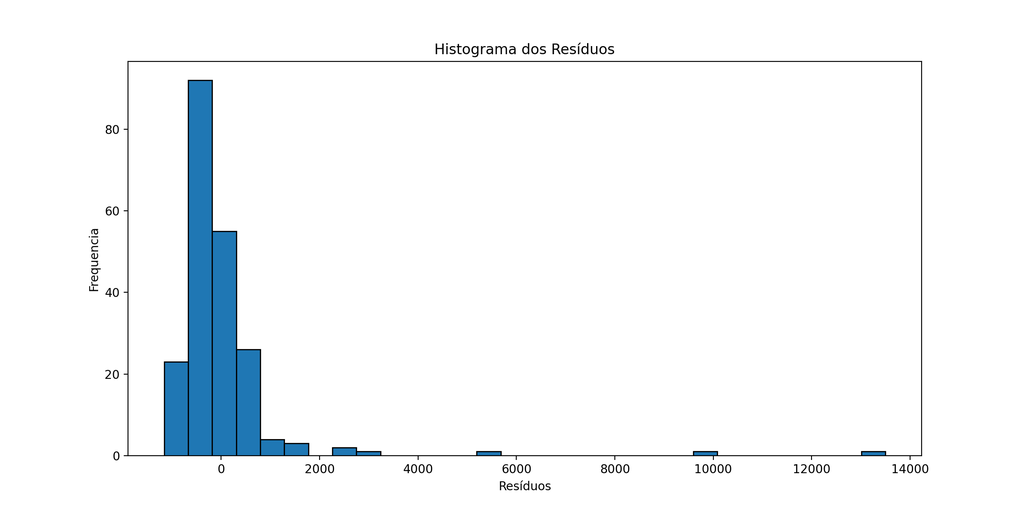

```python
# Histograma dos residuos
plt.figure(figsize=(12, 6))
plt.hist(residuals, bins=30, edgecolor='black')
plt.title('Histograma dos Resíduos')
plt.xlabel('Resíduos')
plt.ylabel('Frequencia')
```

```python
# Q-Q plot
plt.figure(figsize=(12, 6))
stats.probplot(residuals, dist="norm", plot=plt)
```

[output not shown]

[output cut: 39 more lines]

[output not shown]

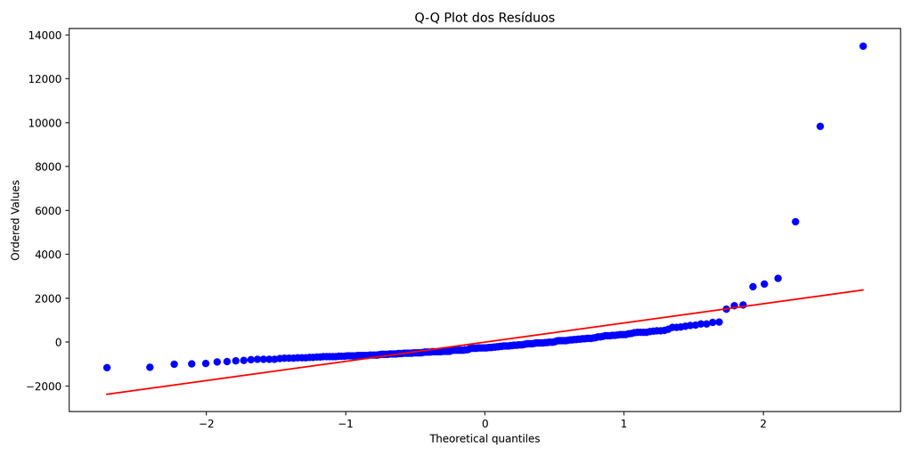

```python
plt.title('Q-Q Plot dos Resíduos')
plt.tight_layout()
plt.show();
```

Esse Q-Q Plot (quantile-quantile plot) compara os quantis teóricos de uma normal padrão (no eixo x) com os quantis dos seus resíduos observados (no eixo y). A Linha vermelha é a referência, ou seja, como os pontos ficariam se os resíduos fossem perfeitamente normais. Já os pontos azuis são os valores observados ordenados (resíduos). Quanto mais os pontos seguirem a linha vermelha, mais próximos de uma normalidade estão os resíduos.

Como visto no gráfico, muitos pontos sobem bem acima da linha. Isso mostra caudas pesadas / outliers no topo, ou seja, há valores muito grandes em relação ao esperado numa normal. Na parte central, a maioria dos pontos no meio do gráfico segue razoavelmente a linha. Então, na média, os resíduos não se afastam tanto da normalidade, mas as caudas estragam o ajuste. Os resíduos não seguem uma distribuição Normal.